# Optimal Treatment Analysis

## Outcome Variable

**Outcome Variable:** ever_stunted

## Predictor Variables

**Intervention Variable:** earlybf

**Adjustment Set:**

- arm
- sex
- W_mage
- meducyrs
- feducyrs
- hhwealth_quart
- hfoodsec
- W_mhtcm
- vagbrth
- W_birthwt
- W_birthlen
- W_nrooms
- brthmon
- W_parity
- impfloor
- impsan
- safeh20
- delta_W_mage
- delta_meducyrs
- delta_feducyrs
- delta_hhwealth_quart
- delta_hfoodsec
- delta_W_mhtcm
- delta_vagbrth
- delta_W_birthwt
- delta_W_birthlen
- delta_W_nrooms
- delta_brthmon
- delta_W_parity
- delta_impfloor
- delta_impsan
- delta_safeh20

## Stratifying Variables

The analysis was stratified on these variable(s):

- agecat
- studyid
- country

## Data Summary

| agecat | studyid | country | earlybf | ever_stunted | n_cell | n |
| --- | --- | --- | --- | --- | --- | --- |
| 0-24 months (no birth st.) | ki0047075b-MAL-ED | BANGLADESH | 1 | 0 | 66 | 216 |
| 0-24 months (no birth st.) | ki0047075b-MAL-ED | BANGLADESH | 1 | 1 | 72 | 216 |
| 0-24 months (no birth st.) | ki0047075b-MAL-ED | BANGLADESH | 0 | 0 | 38 | 216 |
| 0-24 months (no birth st.) | ki0047075b-MAL-ED | BANGLADESH | 0 | 1 | 40 | 216 |
| 0-24 months (no birth st.) | ki0047075b-MAL-ED | BRAZIL | 1 | 0 | 83 | 208 |
| 0-24 months (no birth st.) | ki0047075b-MAL-ED | BRAZIL | 1 | 1 | 17 | 208 |
| 0-24 months (no birth st.) | ki0047075b-MAL-ED | BRAZIL | 0 | 0 | 96 | 208 |
| 0-24 months (no birth st.) | ki0047075b-MAL-ED | BRAZIL | 0 | 1 | 12 | 208 |
| 0-24 months (no birth st.) | ki0047075b-MAL-ED | INDIA | 1 | 0 | 61 | 208 |
| 0-24 months (no birth st.) | ki0047075b-MAL-ED | INDIA | 1 | 1 | 67 | 208 |
| 0-24 months (no birth st.) | ki0047075b-MAL-ED | INDIA | 0 | 0 | 39 | 208 |
| 0-24 months (no birth st.) | ki0047075b-MAL-ED | INDIA | 0 | 1 | 41 | 208 |
| 0-24 months (no birth st.) | ki0047075b-MAL-ED | NEPAL | 1 | 0 | 65 | 212 |
| 0-24 months (no birth st.) | ki0047075b-MAL-ED | NEPAL | 1 | 1 | 25 | 212 |
| 0-24 months (no birth st.) | ki0047075b-MAL-ED | NEPAL | 0 | 0 | 92 | 212 |
| 0-24 months (no birth st.) | ki0047075b-MAL-ED | NEPAL | 0 | 1 | 30 | 212 |
| 0-24 months (no birth st.) | ki0047075b-MAL-ED | PERU | 1 | 0 | 85 | 266 |
| 0-24 months (no birth st.) | ki0047075b-MAL-ED | PERU | 1 | 1 | 117 | 266 |
| 0-24 months (no birth st.) | ki0047075b-MAL-ED | PERU | 0 | 0 | 30 | 266 |
| 0-24 months (no birth st.) | ki0047075b-MAL-ED | PERU | 0 | 1 | 34 | 266 |
| 0-24 months (no birth st.) | ki0047075b-MAL-ED | SOUTH AFRICA | 1 | 0 | 81 | 265 |
| 0-24 months (no birth st.) | ki0047075b-MAL-ED | SOUTH AFRICA | 1 | 1 | 86 | 265 |
| 0-24 months (no birth st.) | ki0047075b-MAL-ED | SOUTH AFRICA | 0 | 0 | 51 | 265 |
| 0-24 months (no birth st.) | ki0047075b-MAL-ED | SOUTH AFRICA | 0 | 1 | 47 | 265 |
| 0-24 months (no birth st.) | ki0047075b-MAL-ED | TANZANIA, UNITED REPUBLIC OF | 1 | 0 | 33 | 219 |
| 0-24 months (no birth st.) | ki0047075b-MAL-ED | TANZANIA, UNITED REPUBLIC OF | 1 | 1 | 151 | 219 |
| 0-24 months (no birth st.) | ki0047075b-MAL-ED | TANZANIA, UNITED REPUBLIC OF | 0 | 0 | 8 | 219 |
| 0-24 months (no birth st.) | ki0047075b-MAL-ED | TANZANIA, UNITED REPUBLIC OF | 0 | 1 | 27 | 219 |
| 0-24 months (no birth st.) | ki1000109-EE | PAKISTAN | 1 | 0 | 10 | 249 |
| 0-24 months (no birth st.) | ki1000109-EE | PAKISTAN | 1 | 1 | 39 | 249 |

[output cut: 138 more lines]

The following strata were considered:

- agecat: 0-24 months (no birth st.), studyid: ki0047075b-MAL-ED, country: BANGLADESH
- agecat: 0-24 months (no birth st.), studyid: ki0047075b-MAL-ED, country: BRAZIL
- agecat: 0-24 months (no birth st.), studyid: ki0047075b-MAL-ED, country: INDIA
- agecat: 0-24 months (no birth st.), studyid: ki0047075b-MAL-ED, country: NEPAL
- agecat: 0-24 months (no birth st.), studyid: ki0047075b-MAL-ED, country: PERU
- agecat: 0-24 months (no birth st.), studyid: ki0047075b-MAL-ED, country: SOUTH AFRICA
- agecat: 0-24 months (no birth st.), studyid: ki0047075b-MAL-ED, country: TANZANIA, UNITED REPUBLIC OF
- agecat: 0-24 months (no birth st.), studyid: ki1000109-EE, country: PAKISTAN
- agecat: 0-24 months (no birth st.), studyid: ki1000304b-SAS-CompFeed, country: INDIA
- agecat: 0-24 months (no birth st.), studyid: ki1017093c-NIH-Crypto, country: BANGLADESH
- agecat: 0-24 months (no birth st.), studyid: ki1113344-GMS-Nepal, country: NEPAL
- agecat: 0-24 months (no birth st.), studyid: ki1126311-ZVITAMBO, country: ZIMBABWE
- agecat: 0-24 months (no birth st.), studyid: kiGH5241-JiVitA-3, country: BANGLADESH
- agecat: 0-24 months (no birth st.), studyid: kiGH5241-JiVitA-4, country: BANGLADESH
- agecat: 0-6 months (no birth st.), studyid: ki0047075b-MAL-ED, country: BANGLADESH
- agecat: 0-6 months (no birth st.), studyid: ki0047075b-MAL-ED, country: BRAZIL
- agecat: 0-6 months (no birth st.), studyid: ki0047075b-MAL-ED, country: INDIA
- agecat: 0-6 months (no birth st.), studyid: ki0047075b-MAL-ED, country: NEPAL
- agecat: 0-6 months (no birth st.), studyid: ki0047075b-MAL-ED, country: PERU
- agecat: 0-6 months (no birth st.), studyid: ki0047075b-MAL-ED, country: SOUTH AFRICA
- agecat: 0-6 months (no birth st.), studyid: ki0047075b-MAL-ED, country: TANZANIA, UNITED REPUBLIC OF
- agecat: 0-6 months (no birth st.), studyid: ki1000109-EE, country: PAKISTAN
- agecat: 0-6 months (no birth st.), studyid: ki1000304b-SAS-CompFeed, country: INDIA
- agecat: 0-6 months (no birth st.), studyid: ki1017093c-NIH-Crypto, country: BANGLADESH
- agecat: 0-6 months (no birth st.), studyid: ki1113344-GMS-Nepal, country: NEPAL
- agecat: 0-6 months (no birth st.), studyid: ki1126311-ZVITAMBO, country: ZIMBABWE
- agecat: 0-6 months (no birth st.), studyid: kiGH5241-JiVitA-3, country: BANGLADESH
- agecat: 0-6 months (no birth st.), studyid: kiGH5241-JiVitA-4, country: BANGLADESH
- agecat: 6-24 months, studyid: ki0047075b-MAL-ED, country: BANGLADESH
- agecat: 6-24 months, studyid: ki0047075b-MAL-ED, country: BRAZIL
- agecat: 6-24 months, studyid: ki0047075b-MAL-ED, country: INDIA
- agecat: 6-24 months, studyid: ki0047075b-MAL-ED, country: NEPAL
- agecat: 6-24 months, studyid: ki0047075b-MAL-ED, country: PERU
- agecat: 6-24 months, studyid: ki0047075b-MAL-ED, country: SOUTH AFRICA
- agecat: 6-24 months, studyid: ki0047075b-MAL-ED, country: TANZANIA, UNITED REPUBLIC OF
- agecat: 6-24 months, studyid: ki1000109-EE, country: PAKISTAN
- agecat: 6-24 months, studyid: ki1000304b-SAS-CompFeed, country: INDIA
- agecat: 6-24 months, studyid: ki1017093c-NIH-Crypto, country: BANGLADESH
- agecat: 6-24 months, studyid: ki1113344-GMS-Nepal, country: NEPAL
- agecat: 6-24 months, studyid: ki1126311-ZVITAMBO, country: ZIMBABWE
- agecat: 6-24 months, studyid: kiGH5241-JiVitA-3, country: BANGLADESH
- agecat: 6-24 months, studyid: kiGH5241-JiVitA-4, country: BANGLADESH

### Dropped Strata

Some strata were dropped due to rare outcomes:

- agecat: 6-24 months, studyid: ki0047075b-MAL-ED, country: BRAZIL
- agecat: 6-24 months, studyid: kiGH5241-JiVitA-3, country: BANGLADESH

## Methods Detail

We’re interested in the causal parameters $E[Y_a]$ for all values of $a \in \mathcal{A}$. These parameters represent the mean outcome if, possibly contrary to fact, we intervened to set all units to have $A=a$. Under the randomization and positivity assumptions, these are identified by the statistical parameters $\psi_a=E_W[E_{Y|A,W}(Y|A=a,W)]$. In addition, we’re interested in the mean of $Y$, $E[Y]$ under no intervention (the observed mean). We will estimate these parameters by using SuperLearner to fit the relevant likelihood factors – $E_{Y|A,W}(Y|A=a,W)$ and $p(A=a|W)$, and then updating our likelihood fit using a joint TMLE.

For unadjusted analyses ($W=\{\}$), initial likelihoods were estimated using Lrnr_glm to estimate the simple $E(Y|A)$ and Lrnr_mean to estimate $p(A)$. For adjusted analyses, a small library containing Lrnr_glmnet, Lrnr_xgboost, and Lrnr_mean was used.

Having estimated these parameters, we will then use the delta method to estimate relative risks and attributable risks relative to a prespecified baseline level of $A$.

# Results Detail

## Results Plots

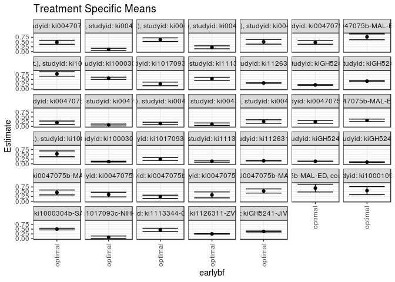

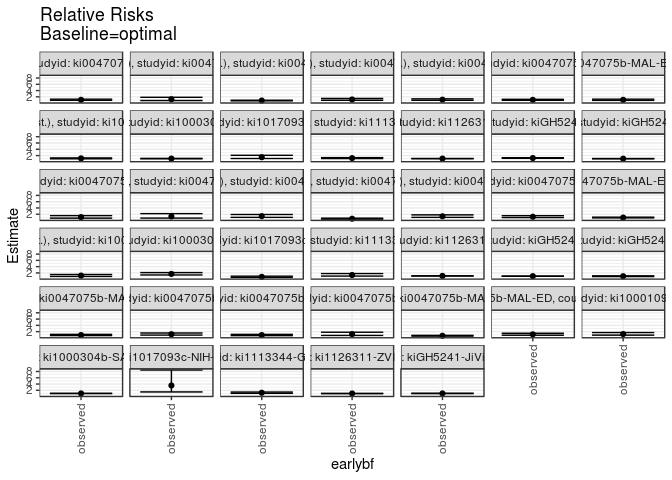

## Results Table

### Parameter: TSM

| agecat | studyid | country | intervention_level | baseline_level | estimate | ci_lower | ci_upper |
| --- | --- | --- | --- | --- | --- | --- | --- |
| 0-24 months (no birth st.) | ki0047075b-MAL-ED | BANGLADESH | optimal | NA | 0.4872683 | 0.3822137 | 0.5923229 |
| 0-24 months (no birth st.) | ki0047075b-MAL-ED | BRAZIL | optimal | NA | 0.1123698 | 0.0521802 | 0.1725594 |
| 0-24 months (no birth st.) | ki0047075b-MAL-ED | INDIA | optimal | NA | 0.6252834 | 0.5319694 | 0.7185973 |
| 0-24 months (no birth st.) | ki0047075b-MAL-ED | NEPAL | optimal | NA | 0.2233238 | 0.1453287 | 0.3013190 |
| 0-24 months (no birth st.) | ki0047075b-MAL-ED | PERU | optimal | NA | 0.5145542 | 0.3913581 | 0.6377503 |
| 0-24 months (no birth st.) | ki0047075b-MAL-ED | SOUTH AFRICA | optimal | NA | 0.4790072 | 0.3845752 | 0.5734392 |
| 0-24 months (no birth st.) | ki0047075b-MAL-ED | TANZANIA, UNITED REPUBLIC OF | optimal | NA | 0.7722047 | 0.6191548 | 0.9252546 |
| 0-24 months (no birth st.) | ki1000109-EE | PAKISTAN | optimal | NA | 0.7903869 | 0.6724860 | 0.9082877 |
| 0-24 months (no birth st.) | ki1000304b-SAS-CompFeed | INDIA | optimal | NA | 0.5628479 | 0.5058201 | 0.6198757 |
| 0-24 months (no birth st.) | ki1017093c-NIH-Crypto | BANGLADESH | optimal | NA | 0.2662241 | 0.1712048 | 0.3612434 |
| 0-24 months (no birth st.) | ki1113344-GMS-Nepal | NEPAL | optimal | NA | 0.5338329 | 0.4511252 | 0.6165407 |
| 0-24 months (no birth st.) | ki1126311-ZVITAMBO | ZIMBABWE | optimal | NA | 0.3143892 | 0.3026246 | 0.3261537 |
| 0-24 months (no birth st.) | kiGH5241-JiVitA-3 | BANGLADESH | optimal | NA | 0.2126785 | 0.1957162 | 0.2296407 |
| 0-24 months (no birth st.) | kiGH5241-JiVitA-4 | BANGLADESH | optimal | NA | 0.4120862 | 0.3855583 | 0.4386141 |
| 0-6 months (no birth st.) | ki0047075b-MAL-ED | BANGLADESH | optimal | NA | 0.1955373 | 0.1086725 | 0.2824021 |
| 0-6 months (no birth st.) | ki0047075b-MAL-ED | BRAZIL | optimal | NA | 0.0739166 | 0.0238969 | 0.1239363 |
| 0-6 months (no birth st.) | ki0047075b-MAL-ED | INDIA | optimal | NA | 0.1528032 | 0.0869346 | 0.2186718 |
| 0-6 months (no birth st.) | ki0047075b-MAL-ED | NEPAL | optimal | NA | 0.1158729 | 0.0514717 | 0.1802741 |
| 0-6 months (no birth st.) | ki0047075b-MAL-ED | PERU | optimal | NA | 0.2571526 | 0.1656426 | 0.3486627 |
| 0-6 months (no birth st.) | ki0047075b-MAL-ED | SOUTH AFRICA | optimal | NA | 0.2396242 | 0.1653160 | 0.3139324 |
| 0-6 months (no birth st.) | ki0047075b-MAL-ED | TANZANIA, UNITED REPUBLIC OF | optimal | NA | 0.3171412 | 0.2485057 | 0.3857767 |
| 0-6 months (no birth st.) | ki1000109-EE | PAKISTAN | optimal | NA | 0.5234902 | 0.3699395 | 0.6770410 |
| 0-6 months (no birth st.) | ki1000304b-SAS-CompFeed | INDIA | optimal | NA | 0.1171239 | 0.0956236 | 0.1386242 |
| 0-6 months (no birth st.) | ki1017093c-NIH-Crypto | BANGLADESH | optimal | NA | 0.2528483 | 0.1778707 | 0.3278258 |
| 0-6 months (no birth st.) | ki1113344-GMS-Nepal | NEPAL | optimal | NA | 0.1373612 | 0.0870585 | 0.1876640 |
| 0-6 months (no birth st.) | ki1126311-ZVITAMBO | ZIMBABWE | optimal | NA | 0.1614409 | 0.1522940 | 0.1705877 |
| 0-6 months (no birth st.) | kiGH5241-JiVitA-3 | BANGLADESH | optimal | NA | 0.1364986 | 0.1299088 | 0.1430884 |
| 0-6 months (no birth st.) | kiGH5241-JiVitA-4 | BANGLADESH | optimal | NA | 0.0903700 | 0.0751934 | 0.1055466 |
| 6-24 months | ki0047075b-MAL-ED | BANGLADESH | optimal | NA | 0.4601602 | 0.3317564 | 0.5885640 |
| 6-24 months | ki0047075b-MAL-ED | INDIA | optimal | NA | 0.3511421 | 0.2284210 | 0.4738632 |
| 6-24 months | ki0047075b-MAL-ED | NEPAL | optimal | NA | 0.2339566 | 0.1496084 | 0.3183047 |
| 6-24 months | ki0047075b-MAL-ED | PERU | optimal | NA | 0.3325667 | 0.1759475 | 0.4891860 |
| 6-24 months | ki0047075b-MAL-ED | SOUTH AFRICA | optimal | NA | 0.5389844 | 0.4296748 | 0.6482941 |
| 6-24 months | ki0047075b-MAL-ED | TANZANIA, UNITED REPUBLIC OF | optimal | NA | 0.6903472 | 0.4863681 | 0.8943263 |
| 6-24 months | ki1000109-EE | PAKISTAN | optimal | NA | 0.5561613 | 0.3438646 | 0.7684580 |
| 6-24 months | ki1000304b-SAS-CompFeed | INDIA | optimal | NA | 0.5028509 | 0.4590263 | 0.5466755 |
| 6-24 months | ki1017093c-NIH-Crypto | BANGLADESH | optimal | NA | 0.0742393 | 0.0080412 | 0.1404373 |
| 6-24 months | ki1113344-GMS-Nepal | NEPAL | optimal | NA | 0.4570957 | 0.3668488 | 0.5473426 |
| 6-24 months | ki1126311-ZVITAMBO | ZIMBABWE | optimal | NA | 0.2504365 | 0.2362726 | 0.2646004 |
| 6-24 months | kiGH5241-JiVitA-4 | BANGLADESH | optimal | NA | 0.3772942 | 0.3504480 | 0.4041404 |

### Parameter: E(Y)

| agecat | studyid | country | intervention_level | baseline_level | estimate | ci_lower | ci_upper |
| --- | --- | --- | --- | --- | --- | --- | --- |
| 0-24 months (no birth st.) | ki0047075b-MAL-ED | BANGLADESH | observed | NA | 0.5185185 | 0.4517302 | 0.5853069 |
| 0-24 months (no birth st.) | ki0047075b-MAL-ED | BRAZIL | observed | NA | 0.1394231 | 0.0922358 | 0.1866104 |
| 0-24 months (no birth st.) | ki0047075b-MAL-ED | INDIA | observed | NA | 0.5192308 | 0.4511677 | 0.5872938 |
| 0-24 months (no birth st.) | ki0047075b-MAL-ED | NEPAL | observed | NA | 0.2594340 | 0.2002911 | 0.3185768 |
| 0-24 months (no birth st.) | ki0047075b-MAL-ED | PERU | observed | NA | 0.5676692 | 0.5080232 | 0.6273151 |
| 0-24 months (no birth st.) | ki0047075b-MAL-ED | SOUTH AFRICA | observed | NA | 0.5018868 | 0.4415735 | 0.5622001 |
| 0-24 months (no birth st.) | ki0047075b-MAL-ED | TANZANIA, UNITED REPUBLIC OF | observed | NA | 0.8127854 | 0.7610035 | 0.8645672 |
| 0-24 months (no birth st.) | ki1000109-EE | PAKISTAN | observed | NA | 0.8674699 | 0.8252704 | 0.9096693 |
| 0-24 months (no birth st.) | ki1000304b-SAS-CompFeed | INDIA | observed | NA | 0.5804327 | 0.5278252 | 0.6330403 |
| 0-24 months (no birth st.) | ki1017093c-NIH-Crypto | BANGLADESH | observed | NA | 0.3935681 | 0.3560687 | 0.4310676 |
| 0-24 months (no birth st.) | ki1113344-GMS-Nepal | NEPAL | observed | NA | 0.6280488 | 0.5852977 | 0.6707999 |
| 0-24 months (no birth st.) | ki1126311-ZVITAMBO | ZIMBABWE | observed | NA | 0.3237628 | 0.3151026 | 0.3324231 |
| 0-24 months (no birth st.) | kiGH5241-JiVitA-3 | BANGLADESH | observed | NA | 0.2544842 | 0.2466711 | 0.2622973 |
| 0-24 months (no birth st.) | kiGH5241-JiVitA-4 | BANGLADESH | observed | NA | 0.4135358 | 0.3953404 | 0.4317312 |
| 0-6 months (no birth st.) | ki0047075b-MAL-ED | BANGLADESH | observed | NA | 0.2129630 | 0.1582389 | 0.2676870 |
| 0-6 months (no birth st.) | ki0047075b-MAL-ED | BRAZIL | observed | NA | 0.0961538 | 0.0559939 | 0.1363138 |
| 0-6 months (no birth st.) | ki0047075b-MAL-ED | INDIA | observed | NA | 0.2115385 | 0.1559035 | 0.2671734 |
| 0-6 months (no birth st.) | ki0047075b-MAL-ED | NEPAL | observed | NA | 0.0660377 | 0.0325283 | 0.0995472 |
| 0-6 months (no birth st.) | ki0047075b-MAL-ED | PERU | observed | NA | 0.3458647 | 0.2885967 | 0.4031327 |
| 0-6 months (no birth st.) | ki0047075b-MAL-ED | SOUTH AFRICA | observed | NA | 0.2867925 | 0.2322370 | 0.3413479 |
| 0-6 months (no birth st.) | ki0047075b-MAL-ED | TANZANIA, UNITED REPUBLIC OF | observed | NA | 0.2968037 | 0.2361590 | 0.3574483 |
| 0-6 months (no birth st.) | ki1000109-EE | PAKISTAN | observed | NA | 0.6024096 | 0.5415000 | 0.6633193 |
| 0-6 months (no birth st.) | ki1000304b-SAS-CompFeed | INDIA | observed | NA | 0.1977401 | 0.1736271 | 0.2218531 |
| 0-6 months (no birth st.) | ki1017093c-NIH-Crypto | BANGLADESH | observed | NA | 0.1898928 | 0.1597870 | 0.2199986 |
| 0-6 months (no birth st.) | ki1113344-GMS-Nepal | NEPAL | observed | NA | 0.1829268 | 0.1487307 | 0.2171229 |
| 0-6 months (no birth st.) | ki1126311-ZVITAMBO | ZIMBABWE | observed | NA | 0.1700741 | 0.1631162 | 0.1770320 |
| 0-6 months (no birth st.) | kiGH5241-JiVitA-3 | BANGLADESH | observed | NA | 0.1316263 | 0.1259812 | 0.1372713 |
| 0-6 months (no birth st.) | kiGH5241-JiVitA-4 | BANGLADESH | observed | NA | 0.0855425 | 0.0741829 | 0.0969021 |
| 6-24 months | ki0047075b-MAL-ED | BANGLADESH | observed | NA | 0.4177215 | 0.3405766 | 0.4948664 |
| 6-24 months | ki0047075b-MAL-ED | INDIA | observed | NA | 0.4129032 | 0.3351414 | 0.4906651 |
| 6-24 months | ki0047075b-MAL-ED | NEPAL | observed | NA | 0.2102564 | 0.1529155 | 0.2675974 |
| 6-24 months | ki0047075b-MAL-ED | PERU | observed | NA | 0.3959732 | 0.3171819 | 0.4747644 |
| 6-24 months | ki0047075b-MAL-ED | SOUTH AFRICA | observed | NA | 0.3630573 | 0.2875961 | 0.4385185 |
| 6-24 months | ki0047075b-MAL-ED | TANZANIA, UNITED REPUBLIC OF | observed | NA | 0.7793103 | 0.7115754 | 0.8470453 |
| 6-24 months | ki1000109-EE | PAKISTAN | observed | NA | 0.6804124 | 0.5871313 | 0.7736934 |
| 6-24 months | ki1000304b-SAS-CompFeed | INDIA | observed | NA | 0.5030750 | 0.4588491 | 0.5473009 |
| 6-24 months | ki1017093c-NIH-Crypto | BANGLADESH | observed | NA | 0.2628458 | 0.2244546 | 0.3012371 |
| 6-24 months | ki1113344-GMS-Nepal | NEPAL | observed | NA | 0.5572519 | 0.5080809 | 0.6064229 |
| 6-24 months | ki1126311-ZVITAMBO | ZIMBABWE | observed | NA | 0.2447019 | 0.2346857 | 0.2547181 |
| 6-24 months | kiGH5241-JiVitA-4 | BANGLADESH | observed | NA | 0.3779118 | 0.3593176 | 0.3965059 |

### Parameter: RR

| agecat | studyid | country | intervention_level | baseline_level | estimate | ci_lower | ci_upper |
| --- | --- | --- | --- | --- | --- | --- | --- |
| 0-24 months (no birth st.) | ki0047075b-MAL-ED | BANGLADESH | observed | optimal | 1.0641335 | 0.8996701 | 1.2586616 |
| 0-24 months (no birth st.) | ki0047075b-MAL-ED | BRAZIL | observed | optimal | 1.2407524 | 0.8269557 | 1.8616069 |
| 0-24 months (no birth st.) | ki0047075b-MAL-ED | INDIA | observed | optimal | 0.8303927 | 0.7448343 | 0.9257792 |
| 0-24 months (no birth st.) | ki0047075b-MAL-ED | NEPAL | observed | optimal | 1.1616940 | 0.9091073 | 1.4844596 |
| 0-24 months (no birth st.) | ki0047075b-MAL-ED | PERU | observed | optimal | 1.1032253 | 0.8968698 | 1.3570599 |
| 0-24 months (no birth st.) | ki0047075b-MAL-ED | SOUTH AFRICA | observed | optimal | 1.0477646 | 0.8958812 | 1.2253976 |
| 0-24 months (no birth st.) | ki0047075b-MAL-ED | TANZANIA, UNITED REPUBLIC OF | observed | optimal | 1.0525517 | 0.8788262 | 1.2606191 |
| 0-24 months (no birth st.) | ki1000109-EE | PAKISTAN | observed | optimal | 1.0975257 | 0.9651509 | 1.2480562 |
| 0-24 months (no birth st.) | ki1000304b-SAS-CompFeed | INDIA | observed | optimal | 1.0312426 | 0.9727741 | 1.0932254 |
| 0-24 months (no birth st.) | ki1017093c-NIH-Crypto | BANGLADESH | observed | optimal | 1.4783341 | 1.0550209 | 2.0714961 |
| 0-24 months (no birth st.) | ki1113344-GMS-Nepal | NEPAL | observed | optimal | 1.1764894 | 1.0334462 | 1.3393317 |
| 0-24 months (no birth st.) | ki1126311-ZVITAMBO | ZIMBABWE | observed | optimal | 1.0298154 | 1.0038234 | 1.0564805 |
| 0-24 months (no birth st.) | kiGH5241-JiVitA-3 | BANGLADESH | observed | optimal | 1.1965677 | 1.1018476 | 1.2994303 |
| 0-24 months (no birth st.) | kiGH5241-JiVitA-4 | BANGLADESH | observed | optimal | 1.0035176 | 0.9541970 | 1.0553875 |
| 0-6 months (no birth st.) | ki0047075b-MAL-ED | BANGLADESH | observed | optimal | 1.0891170 | 0.7609030 | 1.5589054 |
| 0-6 months (no birth st.) | ki0047075b-MAL-ED | BRAZIL | observed | optimal | 1.3008423 | 0.7725200 | 2.1904816 |
| 0-6 months (no birth st.) | ki0047075b-MAL-ED | INDIA | observed | optimal | 1.3843854 | 1.0005267 | 1.9155140 |
| 0-6 months (no birth st.) | ki0047075b-MAL-ED | NEPAL | observed | optimal | 0.5699151 | 0.4404029 | 0.7375139 |
| 0-6 months (no birth st.) | ki0047075b-MAL-ED | PERU | observed | optimal | 1.3449780 | 1.0042382 | 1.8013314 |
| 0-6 months (no birth st.) | ki0047075b-MAL-ED | SOUTH AFRICA | observed | optimal | 1.1968428 | 0.9336478 | 1.5342326 |
| 0-6 months (no birth st.) | ki0047075b-MAL-ED | TANZANIA, UNITED REPUBLIC OF | observed | optimal | 0.9358722 | 0.8307019 | 1.0543575 |
| 0-6 months (no birth st.) | ki1000109-EE | PAKISTAN | observed | optimal | 1.1507562 | 0.8818834 | 1.5016042 |
| 0-6 months (no birth st.) | ki1000304b-SAS-CompFeed | INDIA | observed | optimal | 1.6882989 | 1.3527754 | 2.1070410 |
| 0-6 months (no birth st.) | ki1017093c-NIH-Crypto | BANGLADESH | observed | optimal | 0.7510149 | 0.5790594 | 0.9740337 |
| 0-6 months (no birth st.) | ki1113344-GMS-Nepal | NEPAL | observed | optimal | 1.3317208 | 0.9838687 | 1.8025578 |
| 0-6 months (no birth st.) | ki1126311-ZVITAMBO | ZIMBABWE | observed | optimal | 1.0534760 | 1.0136588 | 1.0948573 |
| 0-6 months (no birth st.) | kiGH5241-JiVitA-3 | BANGLADESH | observed | optimal | 0.9643049 | 0.9396800 | 0.9895751 |
| 0-6 months (no birth st.) | kiGH5241-JiVitA-4 | BANGLADESH | observed | optimal | 0.9465808 | 0.8343058 | 1.0739650 |
| 6-24 months | ki0047075b-MAL-ED | BANGLADESH | observed | optimal | 0.9077741 | 0.7407924 | 1.1123951 |
| 6-24 months | ki0047075b-MAL-ED | INDIA | observed | optimal | 1.1758864 | 0.8869984 | 1.5588628 |
| 6-24 months | ki0047075b-MAL-ED | NEPAL | observed | optimal | 0.8986984 | 0.7168770 | 1.1266352 |
| 6-24 months | ki0047075b-MAL-ED | PERU | observed | optimal | 1.1906578 | 0.7854872 | 1.8048237 |
| 6-24 months | ki0047075b-MAL-ED | SOUTH AFRICA | observed | optimal | 0.6735952 | 0.5705412 | 0.7952632 |
| 6-24 months | ki0047075b-MAL-ED | TANZANIA, UNITED REPUBLIC OF | observed | optimal | 1.1288673 | 0.8623441 | 1.4777643 |
| 6-24 months | ki1000109-EE | PAKISTAN | observed | optimal | 1.2234083 | 0.8806778 | 1.6995182 |
| 6-24 months | ki1000304b-SAS-CompFeed | INDIA | observed | optimal | 1.0004457 | 0.9718111 | 1.0299240 |
| 6-24 months | ki1017093c-NIH-Crypto | BANGLADESH | observed | optimal | 3.5405238 | 1.4808344 | 8.4650308 |
| 6-24 months | ki1113344-GMS-Nepal | NEPAL | observed | optimal | 1.2191144 | 1.0311594 | 1.4413290 |
| 6-24 months | ki1126311-ZVITAMBO | ZIMBABWE | observed | optimal | 0.9771016 | 0.9386595 | 1.0171181 |
| 6-24 months | kiGH5241-JiVitA-4 | BANGLADESH | observed | optimal | 1.0016368 | 0.9506684 | 1.0553379 |

### Parameter: PAR

| agecat | studyid | country | intervention_level | baseline_level | estimate | ci_lower | ci_upper |
| --- | --- | --- | --- | --- | --- | --- | --- |
| 0-24 months (no birth st.) | ki0047075b-MAL-ED | BANGLADESH | optimal | NA | 0.0312502 | -0.0504966 | 0.1129970 |
| 0-24 months (no birth st.) | ki0047075b-MAL-ED | BRAZIL | optimal | NA | 0.0270533 | -0.0191938 | 0.0733004 |
| 0-24 months (no birth st.) | ki0047075b-MAL-ED | INDIA | optimal | NA | -0.1060526 | -0.1721542 | -0.0399510 |
| 0-24 months (no birth st.) | ki0047075b-MAL-ED | NEPAL | optimal | NA | 0.0361101 | -0.0185326 | 0.0907528 |
| 0-24 months (no birth st.) | ki0047075b-MAL-ED | PERU | optimal | NA | 0.0531150 | -0.0531499 | 0.1593799 |
| 0-24 months (no birth st.) | ki0047075b-MAL-ED | SOUTH AFRICA | optimal | NA | 0.0228796 | -0.0521939 | 0.0979531 |
| 0-24 months (no birth st.) | ki0047075b-MAL-ED | TANZANIA, UNITED REPUBLIC OF | optimal | NA | 0.0405807 | -0.0984356 | 0.1795970 |
| 0-24 months (no birth st.) | ki1000109-EE | PAKISTAN | optimal | NA | 0.0770830 | -0.0235604 | 0.1777264 |
| 0-24 months (no birth st.) | ki1000304b-SAS-CompFeed | INDIA | optimal | NA | 0.0175848 | -0.0155094 | 0.0506791 |
| 0-24 months (no birth st.) | ki1017093c-NIH-Crypto | BANGLADESH | optimal | NA | 0.1273441 | 0.0375619 | 0.2171262 |
| 0-24 months (no birth st.) | ki1113344-GMS-Nepal | NEPAL | optimal | NA | 0.0942159 | 0.0256498 | 0.1627819 |
| 0-24 months (no birth st.) | ki1126311-ZVITAMBO | ZIMBABWE | optimal | NA | 0.0093737 | 0.0013386 | 0.0174087 |
| 0-24 months (no birth st.) | kiGH5241-JiVitA-3 | BANGLADESH | optimal | NA | 0.0418057 | 0.0238733 | 0.0597381 |
| 0-24 months (no birth st.) | kiGH5241-JiVitA-4 | BANGLADESH | optimal | NA | 0.0014495 | -0.0193231 | 0.0222221 |
| 0-6 months (no birth st.) | ki0047075b-MAL-ED | BANGLADESH | optimal | NA | 0.0174257 | -0.0527743 | 0.0876257 |
| 0-6 months (no birth st.) | ki0047075b-MAL-ED | BRAZIL | optimal | NA | 0.0222372 | -0.0171371 | 0.0616115 |
| 0-6 months (no birth st.) | ki0047075b-MAL-ED | INDIA | optimal | NA | 0.0587353 | 0.0077430 | 0.1097276 |
| 0-6 months (no birth st.) | ki0047075b-MAL-ED | NEPAL | optimal | NA | -0.0498352 | -0.0878477 | -0.0118227 |
| 0-6 months (no birth st.) | ki0047075b-MAL-ED | PERU | optimal | NA | 0.0887120 | 0.0142579 | 0.1631662 |
| 0-6 months (no birth st.) | ki0047075b-MAL-ED | SOUTH AFRICA | optimal | NA | 0.0471683 | -0.0131724 | 0.1075090 |
| 0-6 months (no birth st.) | ki0047075b-MAL-ED | TANZANIA, UNITED REPUBLIC OF | optimal | NA | -0.0203376 | -0.0575895 | 0.0169143 |
| 0-6 months (no birth st.) | ki1000109-EE | PAKISTAN | optimal | NA | 0.0789194 | -0.0598757 | 0.2177145 |
| 0-6 months (no birth st.) | ki1000304b-SAS-CompFeed | INDIA | optimal | NA | 0.0806162 | 0.0481231 | 0.1131094 |
| 0-6 months (no birth st.) | ki1017093c-NIH-Crypto | BANGLADESH | optimal | NA | -0.0629555 | -0.1288757 | 0.0029648 |
| 0-6 months (no birth st.) | ki1113344-GMS-Nepal | NEPAL | optimal | NA | 0.0455656 | 0.0036757 | 0.0874554 |
| 0-6 months (no birth st.) | ki1126311-ZVITAMBO | ZIMBABWE | optimal | NA | 0.0086332 | 0.0024089 | 0.0148576 |
| 0-6 months (no birth st.) | kiGH5241-JiVitA-3 | BANGLADESH | optimal | NA | -0.0048723 | -0.0083927 | -0.0013519 |
| 0-6 months (no birth st.) | kiGH5241-JiVitA-4 | BANGLADESH | optimal | NA | -0.0048275 | -0.0161523 | 0.0064973 |
| 6-24 months | ki0047075b-MAL-ED | BANGLADESH | optimal | NA | -0.0424387 | -0.1365587 | 0.0516813 |
| 6-24 months | ki0047075b-MAL-ED | INDIA | optimal | NA | 0.0617611 | -0.0371337 | 0.1606559 |
| 6-24 months | ki0047075b-MAL-ED | NEPAL | optimal | NA | -0.0237002 | -0.0772122 | 0.0298118 |
| 6-24 months | ki0047075b-MAL-ED | PERU | optimal | NA | 0.0634064 | -0.0748033 | 0.2016162 |
| 6-24 months | ki0047075b-MAL-ED | SOUTH AFRICA | optimal | NA | -0.1759271 | -0.2567715 | -0.0950827 |
| 6-24 months | ki0047075b-MAL-ED | TANZANIA, UNITED REPUBLIC OF | optimal | NA | 0.0889632 | -0.0959237 | 0.2738500 |
| 6-24 months | ki1000109-EE | PAKISTAN | optimal | NA | 0.1242511 | -0.0557678 | 0.3042699 |
| 6-24 months | ki1000304b-SAS-CompFeed | INDIA | optimal | NA | 0.0002241 | -0.0143821 | 0.0148304 |
| 6-24 months | ki1017093c-NIH-Crypto | BANGLADESH | optimal | NA | 0.1886066 | 0.1196789 | 0.2575343 |
| 6-24 months | ki1113344-GMS-Nepal | NEPAL | optimal | NA | 0.1001562 | 0.0240553 | 0.1762572 |
| 6-24 months | ki1126311-ZVITAMBO | ZIMBABWE | optimal | NA | -0.0057346 | -0.0157831 | 0.0043139 |
| 6-24 months | kiGH5241-JiVitA-4 | BANGLADESH | optimal | NA | 0.0006176 | -0.0190873 | 0.0203225 |

### Parameter: PAF

| agecat | studyid | country | intervention_level | baseline_level | estimate | ci_lower | ci_upper |
| --- | --- | --- | --- | --- | --- | --- | --- |
| 0-24 months (no birth st.) | ki0047075b-MAL-ED | BANGLADESH | optimal | NA | 0.0602683 | -0.1115186 | 0.2055052 |
| 0-24 months (no birth st.) | ki0047075b-MAL-ED | BRAZIL | optimal | NA | 0.1940374 | -0.2092546 | 0.4628297 |
| 0-24 months (no birth st.) | ki0047075b-MAL-ED | INDIA | optimal | NA | -0.2042495 | -0.3425805 | -0.0801712 |
| 0-24 months (no birth st.) | ki0047075b-MAL-ED | NEPAL | optimal | NA | 0.1391881 | -0.0999802 | 0.3263542 |
| 0-24 months (no birth st.) | ki0047075b-MAL-ED | PERU | optimal | NA | 0.0935668 | -0.1149890 | 0.2631128 |
| 0-24 months (no birth st.) | ki0047075b-MAL-ED | SOUTH AFRICA | optimal | NA | 0.0455871 | -0.1162195 | 0.1839384 |
| 0-24 months (no birth st.) | ki0047075b-MAL-ED | TANZANIA, UNITED REPUBLIC OF | optimal | NA | 0.0499279 | -0.1378814 | 0.2067390 |
| 0-24 months (no birth st.) | ki1000109-EE | PAKISTAN | optimal | NA | 0.0888596 | -0.0361074 | 0.1987540 |
| 0-24 months (no birth st.) | ki1000304b-SAS-CompFeed | INDIA | optimal | NA | 0.0302961 | -0.0279879 | 0.0852756 |
| 0-24 months (no birth st.) | ki1017093c-NIH-Crypto | BANGLADESH | optimal | NA | 0.3235629 | 0.0521515 | 0.5172571 |
| 0-24 months (no birth st.) | ki1113344-GMS-Nepal | NEPAL | optimal | NA | 0.1500136 | 0.0323638 | 0.2533590 |
| 0-24 months (no birth st.) | ki1126311-ZVITAMBO | ZIMBABWE | optimal | NA | 0.0289522 | 0.0038088 | 0.0534610 |
| 0-24 months (no birth st.) | kiGH5241-JiVitA-3 | BANGLADESH | optimal | NA | 0.1642763 | 0.0924335 | 0.2304320 |
| 0-24 months (no birth st.) | kiGH5241-JiVitA-4 | BANGLADESH | optimal | NA | 0.0035053 | -0.0480016 | 0.0524807 |
| 0-6 months (no birth st.) | ki0047075b-MAL-ED | BANGLADESH | optimal | NA | 0.0818250 | -0.3142280 | 0.3585243 |
| 0-6 months (no birth st.) | ki0047075b-MAL-ED | BRAZIL | optimal | NA | 0.2312673 | -0.2944649 | 0.5434794 |
| 0-6 months (no birth st.) | ki0047075b-MAL-ED | INDIA | optimal | NA | 0.2776578 | 0.0005264 | 0.4779469 |
| 0-6 months (no birth st.) | ki0047075b-MAL-ED | NEPAL | optimal | NA | -0.7546472 | -1.2706481 | -0.3559066 |
| 0-6 months (no birth st.) | ki0047075b-MAL-ED | PERU | optimal | NA | 0.2564934 | 0.0042203 | 0.4448551 |
| 0-6 months (no birth st.) | ki0047075b-MAL-ED | SOUTH AFRICA | optimal | NA | 0.1644684 | -0.0710677 | 0.3482083 |
| 0-6 months (no birth st.) | ki0047075b-MAL-ED | TANZANIA, UNITED REPUBLIC OF | optimal | NA | -0.0685219 | -0.2038012 | 0.0515551 |
| 0-6 months (no birth st.) | ki1000109-EE | PAKISTAN | optimal | NA | 0.1310062 | -0.1339368 | 0.3340456 |
| 0-6 months (no birth st.) | ki1000304b-SAS-CompFeed | INDIA | optimal | NA | 0.4076878 | 0.2607790 | 0.5254008 |
| 0-6 months (no birth st.) | ki1017093c-NIH-Crypto | BANGLADESH | optimal | NA | -0.3315315 | -0.7269386 | -0.0266585 |
| 0-6 months (no birth st.) | ki1113344-GMS-Nepal | NEPAL | optimal | NA | 0.2490918 | -0.0163958 | 0.4452328 |
| 0-6 months (no birth st.) | ki1126311-ZVITAMBO | ZIMBABWE | optimal | NA | 0.0507615 | 0.0134748 | 0.0866390 |
| 0-6 months (no birth st.) | kiGH5241-JiVitA-3 | BANGLADESH | optimal | NA | -0.0370164 | -0.0641921 | -0.0105347 |
| 0-6 months (no birth st.) | kiGH5241-JiVitA-4 | BANGLADESH | optimal | NA | -0.0564338 | -0.1986013 | 0.0688710 |
| 6-24 months | ki0047075b-MAL-ED | BANGLADESH | optimal | NA | -0.1015956 | -0.3499058 | 0.1010388 |
| 6-24 months | ki0047075b-MAL-ED | INDIA | optimal | NA | 0.1495777 | -0.1273977 | 0.3585067 |
| 6-24 months | ki0047075b-MAL-ED | NEPAL | optimal | NA | -0.1127203 | -0.3949394 | 0.1124012 |
| 6-24 months | ki0047075b-MAL-ED | PERU | optimal | NA | 0.1601281 | -0.2730952 | 0.4459293 |
| 6-24 months | ki0047075b-MAL-ED | SOUTH AFRICA | optimal | NA | -0.4845712 | -0.7527217 | -0.2574453 |
| 6-24 months | ki0047075b-MAL-ED | TANZANIA, UNITED REPUBLIC OF | optimal | NA | 0.1141563 | -0.1596299 | 0.3233021 |
| 6-24 months | ki1000109-EE | PAKISTAN | optimal | NA | 0.1826114 | -0.1354891 | 0.4115979 |
| 6-24 months | ki1000304b-SAS-CompFeed | INDIA | optimal | NA | 0.0004455 | -0.0290065 | 0.0290545 |
| 6-24 months | ki1017093c-NIH-Crypto | BANGLADESH | optimal | NA | 0.7175559 | 0.3247050 | 0.8818669 |
| 6-24 months | ki1113344-GMS-Nepal | NEPAL | optimal | NA | 0.1797324 | 0.0302178 | 0.3061959 |
| 6-24 months | ki1126311-ZVITAMBO | ZIMBABWE | optimal | NA | -0.0234350 | -0.0653491 | 0.0168300 |
| 6-24 months | kiGH5241-JiVitA-4 | BANGLADESH | optimal | NA | 0.0016342 | -0.0518915 | 0.0524362 |